# Operational Risk Audit Model: A Target-Leakage Case Study

Evan Deaver

Revised October 2026 (original: April 15, 2026)

## 1. Summary

The original briefing (April 2026) reported a Random Forest that predicted audit failure with near-perfect accuracy. It named a **“Systemic Risk Factor”** as the dominant driver and **asset exposure** as irrelevant.

Re-examining the data shows the model was **reading the answer key**. The target `Risk` is defined directly from `Audit_Risk`, and `Audit_Risk` is calculated from the same composite score the model ranked first. This revision documents the leak, rebuilds the model without it, and corrects the business conclusions.

## 2. Finding the Leak

| Check | Result |
| --- | --- |
| Risk == (Audit_Risk > 1) | 100.0% of rows |
| Audit_Risk == Inherent_Risk x CONTROL_RISK x Detection_Risk | max difference 1.1e-13 |
| Risk_A == PARA_A x Score_A (sub-scores are derived too) | max difference 7.1e-15 |
| Distinct values of Detection_Risk | 0.5 |

The label is not an independent audit outcome. It is a **threshold applied to a formula**: Risk = 1 exactly when Inherent_Risk × Control_Risk × 0.5 > 1. Any feature that feeds that formula (Inherent_Risk, the Score/Risk sub-columns, Audit_Risk itself) hands the model the answer. The original “Systemic Risk Factor” *was* Inherent_Risk.

## 3. Original Model (kept for comparison)

Features: Systemic Risk Factor (Inherent_Risk), Standard Compliance (PARA_A + PARA_B) and Asset Exposure (Money_Value).

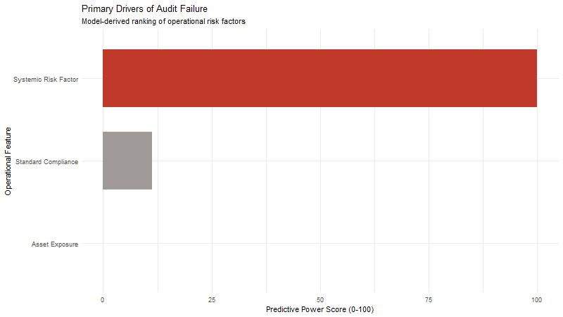

Published chart: Primary Drivers of Audit Failure

## 4. Rebuilt Model: Raw Inputs Only

I removed every engineered column (all Score_*, Risk_*, Inherent_Risk, CONTROL_RISK, Detection_Risk, Audit_Risk, TOTAL, Score, PROB/Prob). I kept only the seven raw measurements an auditor would actually record: `Sector_score`, `PARA_A`, `PARA_B`, `numbers`, `Money_Value`, `District_Loss` and `History`.

| Model | OOB accuracy |
| --- | --- |
| Majority-class baseline (always ‘Pass’) | 60.6% |
| Original (leaky composite features) | 97.8% |
| Rebuilt (raw inputs only) | 98.5% |

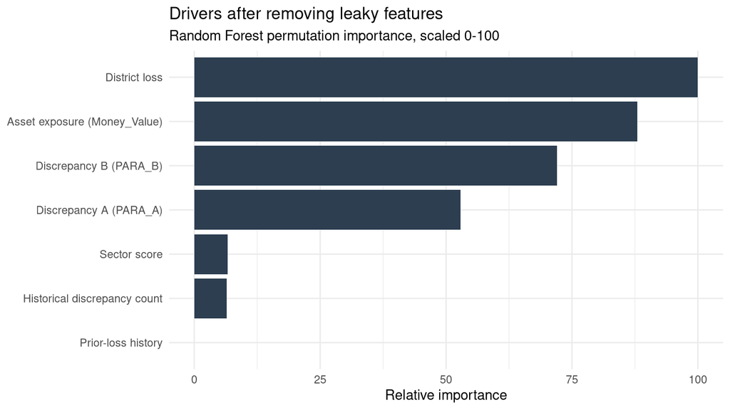

**Why is accuracy still high?** Because the label is a deterministic scoring rule, and the raw inputs are exactly what that rule scores. The rebuilt model isn’t finding hidden risk. It is **re-learning the auditors’ formula**. That is still a useful result, but it means this dataset can’t show that a model predicts real-world audit failure, only that it reproduces an existing policy.

## 5. Corrected Conclusions

- **Asset exposure matters.** The original briefing called financial volume “a poor leading indicator”. Without the leak, Money_Value is one of the strongest drivers, alongside district loss and the two discrepancy amounts. The recommendation to stop prioritising by asset value is reversed.
- **The “Systemic Risk Factor” isn’t a discovery.** It was the target’s own formula. The tier chart and “risk probability above 80%” thresholds built on it are withdrawn.
- **The resource-allocation figures** (70% of field audits, quarterly monitoring) weren’t derived from the model and are withdrawn.

## 6. What I Learned / Next Steps

- **Trace every feature’s lineage before modelling.** If a column is computed from the target, or the target from it, it can’t be used as a predictor.
- **Be suspicious of near-perfect accuracy.** About 98% on a real-world risk problem is a signal to check for leakage, not a result to publish.
- **Next:** obtain an *independent* outcome, such as confirmed fraud or a later audit finding, rather than the rule-based score. Then evaluate with time-based or entity-grouped hold-out data, and compare against a simple logistic regression for interpretability.